# Beta diversity

Yanxian Li Department of Paraclinical Sciences Faculty of Veterinary Medicine Norwegian University of Life Sciences

2021-08-02

# 1 Getting ready

Load packages

```r
library(here) # A Simpler Way to Find Your Files, CRAN
library(tidyverse) # Easily Install and Load the 'Tidyverse', CRAN
library(patchwork) # The Composer of Plots, CRAN
library(flextable) # Functions for Tabular Reporting, CRAN
library(usedist) # Distance Matrix Utilities
library(vegan) # Community Ecology Package, CRAN
```

Load function.

```r
source(here("code/functions/plot_betadisper.R"))
```

Load data

```r
# metadata
mtd <- read_tsv(here("data/metadata.tsv"), comment = "#q2") %>%
  rename(SampleID = "#SampleID") %>%
  filter(Population == "Wild")

# distance matrix
dist <- readRDS(here("data/intermediate/qiime2R/perch/beta_diversity_distance.rds"))
dist_atch <- dist$aitchison$data # Aitchison distance
dist_wuf <- dist$weighted_unifrac$data # weighted UniFrac distance

# ordination
ord <- readRDS(here("data/intermediate/qiime2R/perch/beta_diversity_ordination.rds"))
ord_atch <- ord$aitchison$data # Aitchison distance based PCoA
ord_wuf <- ord$weighted_unifrac$data # weighted UniFrac distance based PCoA
```

# 2 Ordination

Unweighted beta-diversity distance metrics such as unweighted UniFrac are subjective to technical noises, making comparison of results across studies difficult ([Wong et al., 2016](https://doi.org/10.1371/journal.pone.0161196); [Nearing et al., 2018](https://doi.org/10.7717/peerj.5364)). Here we use weighted distance metrics including robust Aitchison distance and weighted UniFrac distance to compare beta-diversity. Robust Aitchison distance is a compositional beta diversity metric rooted in a centered log-ratio (CLR) transformation and matrix completion [(Martino et al., 2019)](https://msystems.asm.org/content/4/1/e00016-19). It has some desirable properties: 1)scale invariant, which ensures equivalence between distances computed from absolute and relative abundance measurements, negating the need to perform rarefaction; 2)relative changes driven. Microbes that display large fold change across samples will be weighted more heavily, which makes the ordination robust to random fluctuations of high-abundant taxa; 3)sub-compositionally coherent, which guarantees that distances will never decrease if additional taxa are observed.

## 2.1 PCoA: robust Aitchison distance

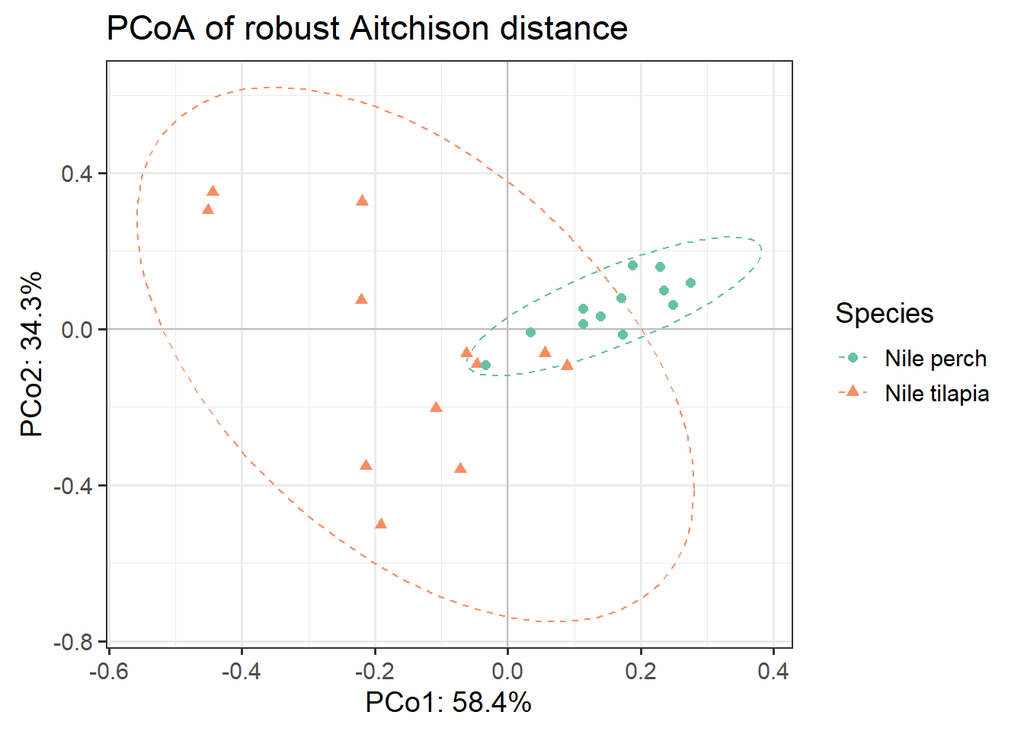

```r
pcoa_atch <- ord_atch$Vectors %>%
  mutate(SampleID = as.character(SampleID)) %>%
  inner_join(mtd, by = "SampleID") %>%
  ggplot(aes(x = PC1, y = PC2, color = Species, shape = Species)) +
    geom_hline(yintercept = 0, color = "grey") +
    geom_vline(xintercept = 0, color = "grey") +
    # data ellipse
    stat_ellipse(linetype = "dashed") +
    geom_point(size = 2) +
    # keep the aspect ratio between y and x axis (y-axis/x-axis)
    coord_fixed(ord_atch$ProportionExplained[2]/ord_atch$ProportionExplained[1]) +
    labs(
      x = paste0("PCo1: ", round(100 * ord_atch$ProportionExplained[1], 1), "%"),
      y = paste0("PCo2: ", round(100 * ord_atch$ProportionExplained[2], 1), "%")
      ) +
    scale_color_brewer(palette = "Set2") +
    theme_bw(base_size = 14)

pcoa_atch + labs(title = "PCoA of robust Aitchison distance")
```

## 2.2 PCoA: weighted UniFrac distance

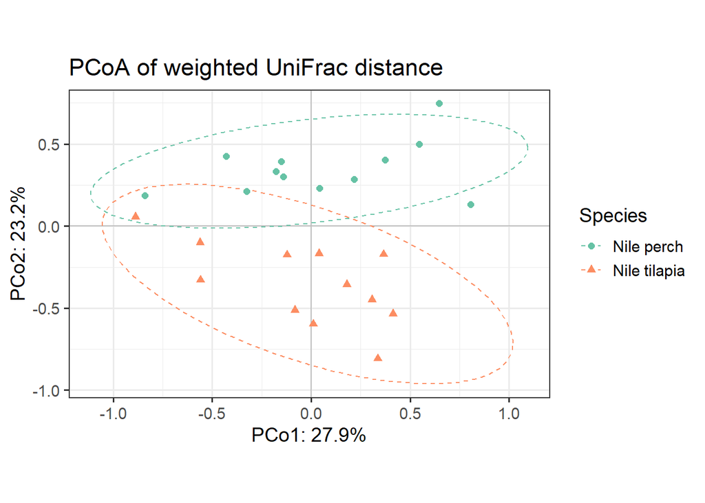

```r
pcoa_wuf <- ord_wuf$Vectors %>%
  mutate(SampleID = as.character(SampleID)) %>%
  inner_join(mtd, by = "SampleID") %>%
  ggplot(aes(x = PC1, y = PC2, color = Species, shape = Species)) +
    geom_hline(yintercept = 0, color = "grey") +
    geom_vline(xintercept = 0, color = "grey") +
    stat_ellipse(linetype = "dashed") +
    geom_point(size = 2) +
    coord_fixed(ord_wuf$ProportionExplained[2]/ord_wuf$ProportionExplained[1]) +
    labs(
      x = paste0("PCo1: ", round(100 * ord_wuf$ProportionExplained[1], 1), "%"),
      y = paste0("PCo2: ", round(100 * ord_wuf$ProportionExplained[2], 1), "%")
      ) +
    scale_color_brewer(palette = "Set2") +
    theme_bw(base_size = 14)

pcoa_wuf + labs(title = "PCoA of weighted UniFrac distance")
```

## 2.3 Figure 4

Assemble plots.

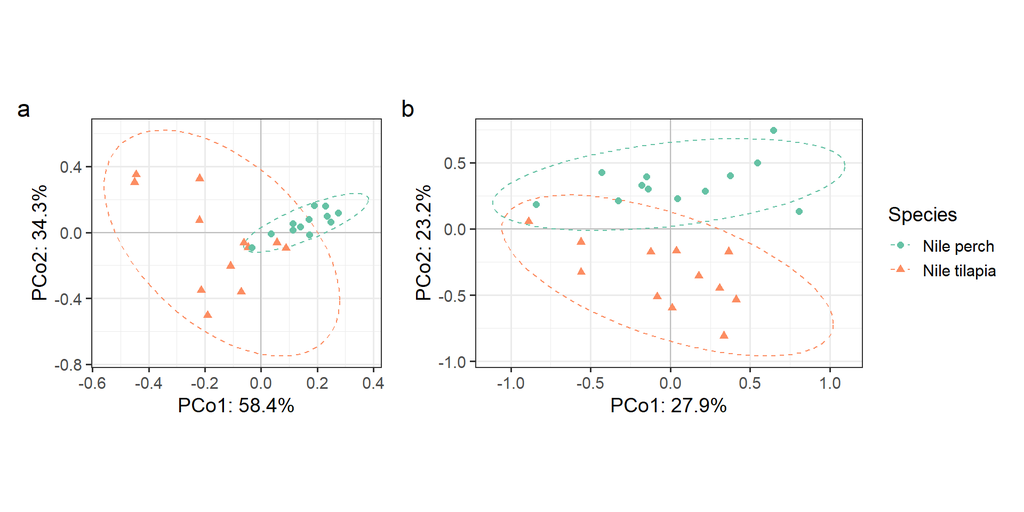

```r
pcoa_atch + pcoa_wuf +
  plot_layout(guides = "collect") +
  plot_annotation(tag_levels = "a")
```

```r
# export plot
ggsave(
  here("result/figure/perch/Figure 4.tiff"), width = 10, units = "in",
  dpi = 300, compression = "lzw"
  )
```

# 3 PERMANVOA

## 3.1 Export distance matrix

We export the distance matrices and run PERMANOVA using the PERMANOVA+ add-on from the [PRIMER v7](https://www.primer-e.com/our-software/permanova-add-on/).

```r
# combine distance matrices into a list
dist_list <- list(dist_atch, dist_wuf)
names(dist_list) <- c("Aitchison_distance", "Weighted_UniFrac_distance")

# export distance matrices
lapply(seq_along(dist_list), function(x) {
  dist_list[[x]] %>%
    as.matrix() %>%
    as.data.frame() %>%
    write.table(
      here(
        paste0("data/intermediate/permanova/perch/", names(dist_list)[x], ".tsv")
        ),
      sep = "\t",
      col.names = NA,
      row.names = TRUE)
    }
  )
```

## 3.2 Import and format PERMANVOA results

```r
# import permanova results
permanova <- read_csv(
  here("data/intermediate/permanova/perch/permanova_results.csv")
  )

# format permanova results
permanova %>%
  flextable() %>%
  set_caption(
    caption = "Table 1. PERMANOVA results based on robust Aitchison and weighted UniFrac distance."
    ) %>%
  autofit() %>%
  merge_v(j = "Distance") %>% # merge cells
  theme_booktabs() %>% # apply table style
  italic(j = 4:5, italic = TRUE, part = "head") %>% # italicize column names
  align(align = "left", part = "all") %>% # align text to the left
  hline(i = 3, j = 2:5, part = "body") # draw horizontal lines
```

Table 1. PERMANOVA results based on robust Aitchison and weighted UniFrac distance.

| Distance | Term | df | Pseudo-F | P |
| --- | --- | --- | --- | --- |
| robust Aitchison | Species | 1 | 13.32 | 0.001 |
|  | Site | 3 | 6.31 | 0.001 |
|  | Residual | 19 |  |  |
| weighted UniFrac | Species | 1 | 3.92 | 0.001 |
|  | Site | 3 | 0.83 | 0.653 |
|  | Residual | 19 |  |  |

# 4 PERMDISP

PERMANOVA tests differences in both location and dispersion effects. Although PERMANOVA is robust to heterogeneity in the multivariate dispersion, it’s a good practice to look at the homogeneity of multivariate dispersion following a significant PERMANVOA result. The homogeneity of multivariate dispersion can be assessed visually (PCoA plot/boxplot) or by a permutation test called PERMDISP, which is implemented in R by the `betadisper()` function from the *vegan* package. When within-group sample sizes are small (n < 5), formal testing with PERMDISP is not very meaningful. Visual assessment is a better option.

## 4.1 Robust Aitchison distance

### 4.1.1 Site-level

First, we check the equality of dispersion for samples (replicates) across different Site (centroids).

Compute beta-dispersion.

```r
# distinguish sites shared by Species
mtd <- mtd %>%
  mutate(
    Site = ifelse(
      grepl("perch", Species),
      paste0("Perch_", Site),
      paste0("Tilapia_", Site)
      )
    )

# compute beta-dispersion
(
disp_atch_site <- betadisper(
  d = dist_atch,
  group = mtd$Site,
  type = "median",
  bias.adjust = TRUE
  )
)
```

```
##
##  Homogeneity of multivariate dispersions
##
## Call: betadisper(d = dist_atch, group = mtd$Site, type = "median", bias.adjust = TRUE)
##
## No. of Positive Eigenvalues: 3
## No. of Negative Eigenvalues: 0
##
## Average distance to median:
##    Perch_Jinja_Lake_site2   Perch_Mukono_Lake_site1   Perch_Wakiso_Lake_site1  Tilapia_Jinja_Lake_site2
##                    0.5038                    0.5976                    0.5706                    0.5714
## Tilapia_Mukono_Lake_site1 Tilapia_Wakiso_Lake_site1 Tilapia_Wakiso_Lake_site2
##                    0.5448                    1.2252                    0.8354
##
## Eigenvalues for PCoA axes:
##  PCoA1  PCoA2  PCoA3
## 24.904 24.326  3.667
```

Visual inspection.

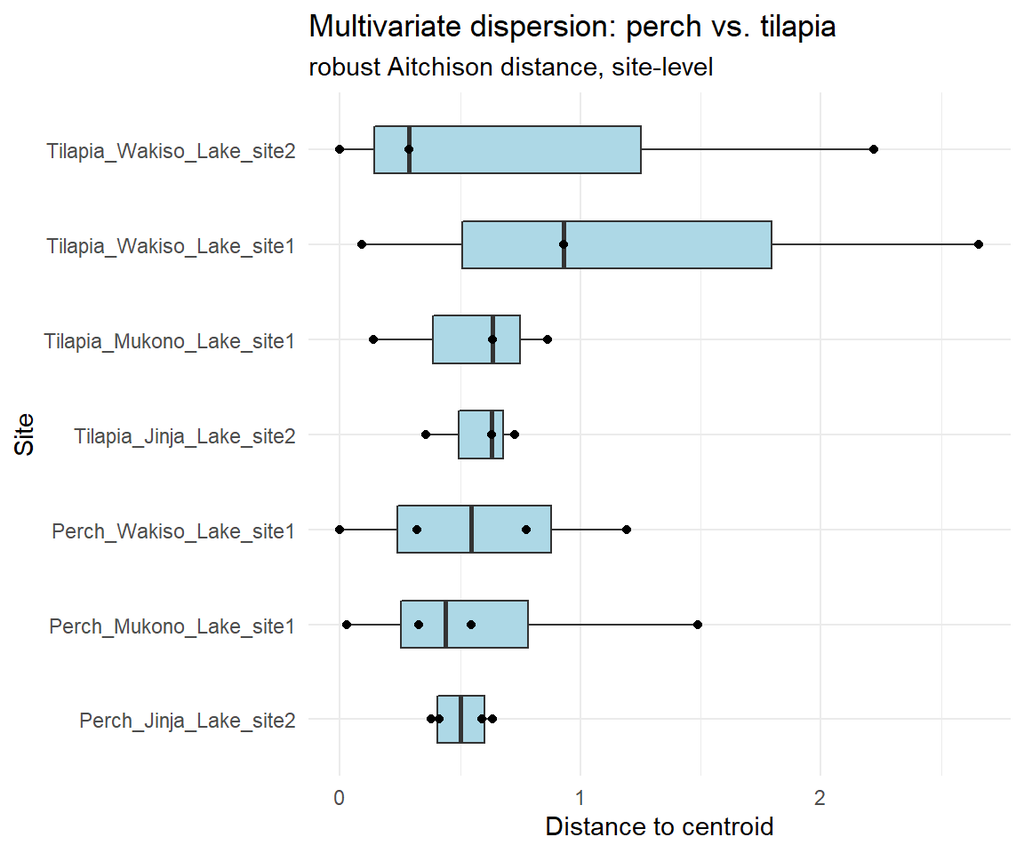

```r
plot_betadisper(
  disp_atch_site,
  xlab = "Site",
  title = "Multivariate dispersion: perch vs. tilapia") +
  labs(subtitle = "robust Aitchison distance, site-level") +
  coord_flip()
```

### 4.1.2 Species-level

Next, we consider differences in the dispersion of Site centroids around the Species centroids.

Compute distance among the Site centroids.

```r
dist_atch_site <- dist_multi_centroids(dist_atch, mtd$Site)
```

Make a new metadata matching Site and Species.

```r
mtd_site <- mtd %>%
  select(Species, Site) %>%
  distinct()%>%
  arrange(Site)
```

Compute beta-dispersion.

```r
(
disp_atch_species <- betadisper(
  d = dist_atch_site,
  group = mtd_site$Species,
  type = "median",
  bias.adjust = TRUE
  )
)
```

```
##
##  Homogeneity of multivariate dispersions
##
## Call: betadisper(d = dist_atch_site, group = mtd_site$Species, type = "median", bias.adjust = TRUE)
##
## No. of Positive Eigenvalues: 3
## No. of Negative Eigenvalues: 0
##
## Average distance to median:
##   Nile perch Nile tilapia
##       0.4058       1.4225
##
## Eigenvalues for PCoA axes:
##  PCoA1  PCoA2  PCoA3
## 6.3883 5.9299 0.4019
```

Visual inspection.

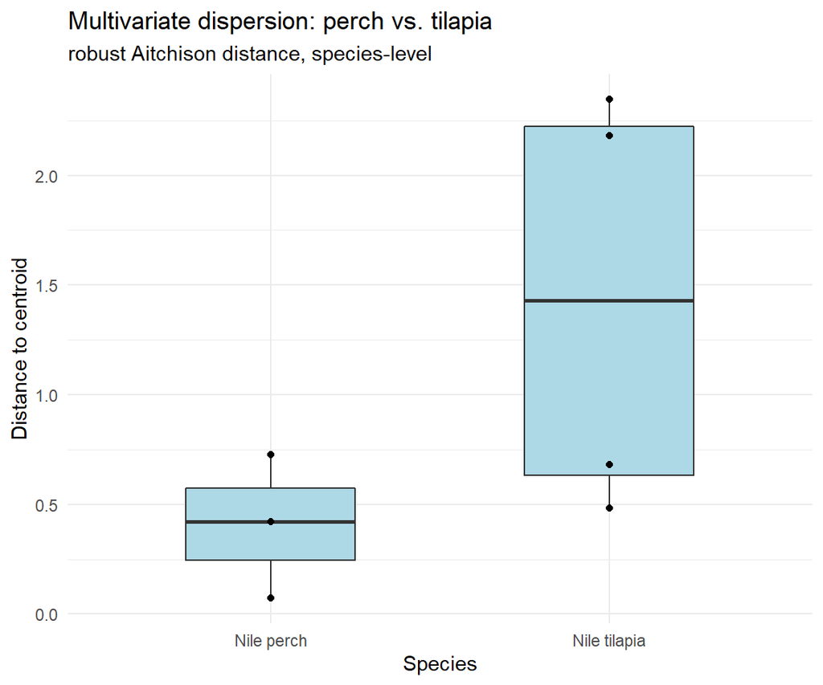

```r
plot_betadisper(
  disp_atch_species,
  xlab = "Species",
  title = "Multivariate dispersion: perch vs. tilapia") +
  labs(subtitle = "robust Aitchison distance, species-level")
```

## 4.2 Weighted UniFrac distance

As PERMANOVA suggests little evidence of Site effect, here we use individual samples for assessing homogeneity of multivariate dispersion at species-level.

### 4.2.1 Species-level

Compute beta-dispersion.

```r
(
disp_wuf <- betadisper(
  d = dist_wuf,
  group = mtd$Species,
  type = "median",
  bias.adjust = TRUE
  )
)
```

```
##
##  Homogeneity of multivariate dispersions
##
## Call: betadisper(d = dist_wuf, group = mtd$Species, type = "median", bias.adjust = TRUE)
##
## No. of Positive Eigenvalues: 16
## No. of Negative Eigenvalues: 7
##
## Average distance to median:
##   Nile perch Nile tilapia
##       0.6828       0.7663
##
## Eigenvalues for PCoA axes:
## (Showing 8 of 23 eigenvalues)
##  PCoA1  PCoA2  PCoA3  PCoA4  PCoA5  PCoA6  PCoA7  PCoA8
## 4.6062 3.8245 2.7977 1.7840 0.9661 0.6127 0.5136 0.4577
```

Formal permutation test with `permutest`.

```r
permutest(disp_wuf, permutations = 999)
```

```
##
## Permutation test for homogeneity of multivariate dispersions
## Permutation: free
## Number of permutations: 999
##
## Response: Distances
##           Df  Sum Sq  Mean Sq     F N.Perm Pr(>F)
## Groups     1 0.04181 0.041809 0.707    999  0.394
## Residuals 22 1.30106 0.059139
```

Visual inspection.

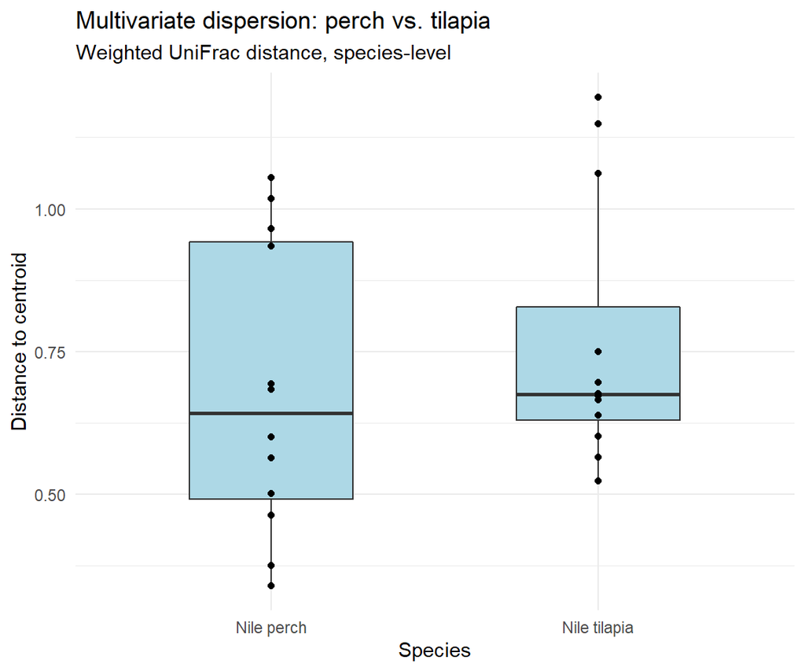

```r
plot_betadisper(
  disp_wuf,
  xlab = "Species",
  title = "Multivariate dispersion: perch vs. tilapia") +
  labs(subtitle = "Weighted UniFrac distance, species-level")
```